# Lab8

Problem 1 - Six sigma

```
[Text(0, 0.5, 'Probability'), Text(0.5, 0, 'Normal')]
```

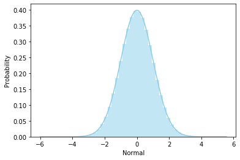

```python
import seaborn as sns
from scipy.stats import norm
data_normal = norm.rvs(size=100000000,loc=0,scale=1)
ax = sns.distplot(data_normal,
                  bins=50,
                  kde=True,
                  color='skyblue',
                  hist_kws={"linewidth": 15,'alpha':0.5})
ax.set(xlabel='Normal', ylabel='Probability')
```

```python
mn = data_normal.mean()
```

```python
mn
```

```
-4.6101166932093736e-05
```

```python
std = data_normal.std()
```

```python
#Probability within sigma - i.e (mean - sigma) and (mean+ sigma)
pb1 = norm.cdf(mn + std, mn, std) - norm.cdf(mn - std, mn, std)
print ("Probability within 1 sigma : ",pb1*100,"%")
```

```
Probability within 1 sigma :  68.26894921370858 %
```

```python
#Probability within 2 sigma
pb2 = norm.cdf(mn + (2*std), mn, std) - norm.cdf(mn - (2*std), mn, std)
print ("Probability within 2 sigma : ",pb2*100,"%")
```

```
Probability within 2 sigma :  95.44997361036415 %
```

```python
#Probability within 3 sigma
pb3 = norm.cdf(mn + (3*std), mn, std) - norm.cdf(mn - (3*std), mn, std)
print ("Probability within 3 sigma : ",pb3*100,"%")
```

```
Probability within 3 sigma :  99.73002039367398 %
```

```python
#Probability within mean +6 sigma and mean - 6sigma
pb3 = norm.cdf(mn + (6*std), mn, std) - norm.cdf(mn - (6*std), mn, std)
print (pb3*100,"%")
```

```
99.99999980268245 %
```

Write python code to find out, in how many σ, the probability is 99.99966%. Is it really 6σ?

```python
pb = 0
i =0
while (pb != 99.99966) :

    pb = round(((norm.cdf(mn + (i*std), mn, std) - norm.cdf(mn - (i*std), mn, std) )* 100 ),6)
    #print(i,pb)
    i +=0.005
i -=0.005
print("Number of sigma = ", round(i,5))
```

```
Number of sigma =  4.645
```

Problem 2 - Job Search.

You are spamming resumes to apply jobs. Each resume you send out has 1% chance of getting a job offer. You have sent 100 resumes. What's your chance to get at least one job offer?

1. Please solve the problem by math. Use python mathematical expression to get the result.

```
        Probability of getting atleast one job offer = 1 - Probability of getting no offer
```

```
            P0 = 100C0 * (0.01)^0 * (0.99)^100

                = 1 * 1 * 0.366 = 0.366

            P_getting_atleast1 = 1 - 0.366 = 0.634
```

```python
import math

def nCr(n,r):
    f = math.factorial
    return f(n) / f(r) / f(n-r)

n = 100
r = 0
P0 =  nCr(n,r) * math.pow(0.01,r) * math.pow(0.99,n-r)
#print(P0)
P_getting_atleast1 = 1- P0
print(round(P_getting_atleast1,3))
```

```
0.634
```

1. Analytic solution. Use pmf function to solve the problem.

```python
from scipy.stats import binom
P0 = binom.pmf(k=0, n=100,p=0.01)
P_getting_atleast1 = 1- P0
print(round(P_getting_atleast1,3))
```

```
0.634
```

1. Answer by simulation. Use rvs function to simulate the process and estimate the answer.

```
[Text(0, 0.5, 'Frequency'), Text(0.5, 0, 'Binomial')]
```

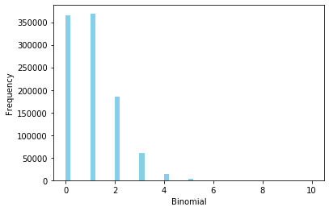

```python
from scipy.stats import binom
import seaborn as sns
import numpy as np
n = 100
p = 0.01
data_binom =  binom.rvs(n, p,size = 1000000)
ax = sns.distplot(data_binom,
kde=False,
color='skyblue',
hist_kws={"linewidth": 15,'alpha':1})
ax.set(xlabel='Binomial', ylabel='Frequency')
```

```python
data_binom
```

```
array([1, 1, 2, ..., 1, 1, 1])
```

```python
num = 0
for i in data_binom:
    if i >= 1:
        num +=1
prob = num / len(data_binom)

print(prob)
```

```
0.634219
```

1. How many resumes in total do you have to spam so that you will have 90% chance to get at least one job offer?

```python
P  = 0
P_ninty =0
i =0
while (P_ninty != 0.90):
    P = binom.pmf(k=0, n=i,p=0.01)
    P_ninty = round(1- P,2)
    #print(i, P_ninty)
    i += 1
print("Resumes to send ",i-1)
```

```
Resumes to send  225
```

Problem 3, President Election Polls Half of the population supports the president (i.e., p=0.5). For a random sample of size 1000, what is the probability of having ≥550 in support of the president?

1. Use binomial distribution
2. Use normal distribution as approximation.

```python
from scipy.stats import binom
1 - binom.cdf(549,n = 1000,p = 0.5)
```

```
0.0008652680424885428
```

```python
from scipy.stats import norm
```

```python
l = np.arange(1,1001,1)
```

```python
l.mean()
```

```
500.5
```

```python
norm_data = norm.rvs(l.mean(),1 , size = 10000000)
```

```python
norm_data
```

```
array([500.07253045, 499.99402034, 498.83561814, ..., 499.72438302,
       501.55115424, 501.26615302])
```

```python
print (1 - norm.cdf(549, norm_data.mean(), norm_data.std()))
```

```
0.0
```